# Linear models to fit exponential growth

11/22/2021

## **Steller sea lion** (*Eumatopias jubatus*) - birth

[interactive chart not shown]

## Linear modeling

## Linear modeling …. aka *REGRESSION*, except I really don’t like that term, for a variety of reasons to discuss in class.

… is a very general method to quantifying relationships among variables.

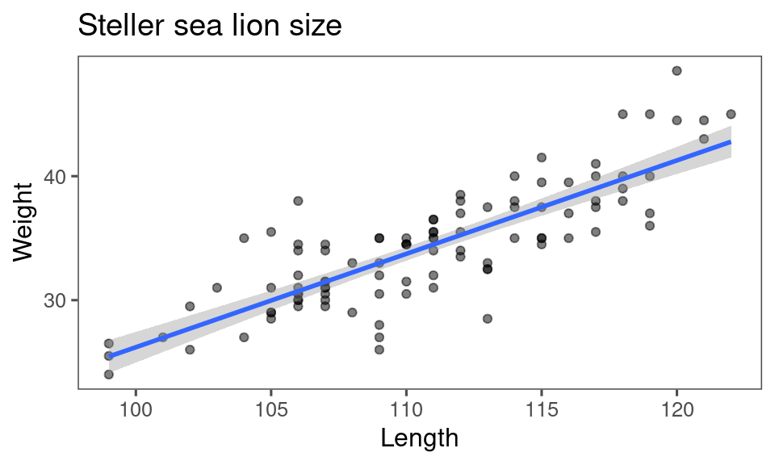


## Linear Models

**Deterministic:**

\[Y_i = a + bX_i\]

\(a\) - intercept; \(b\) - slope

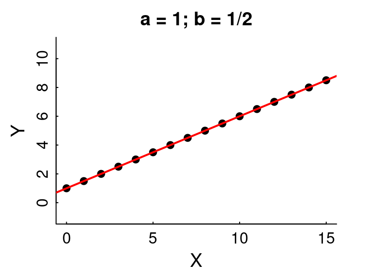

**Statistical:**

\[Y_i = \alpha + \beta X_i + \epsilon_i\]

\(\alpha\) - intercept; \(\beta\) - slope; \(\epsilon\) - **randomness!**

\[\epsilon_i \sim {\cal N}(0, \sigma)\]

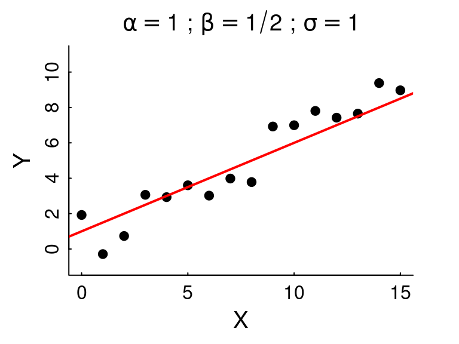

## Some comments on linear models

\[ Y_i \sim \alpha + \beta X_i + \epsilon_i\]

1. \(\epsilon_i\) is **unexplained variation** or **residual variance**. It is often POORLY/WRONGLY referred to as “**error**”. It is a **random variable**, NOT a **parameter**
2. A **better**, more sophisticated way to think of this model is not to focus on isolating the residual variance, but that the whole process is a random variable: \[Y_i \sim {\cal N}(\alpha + \beta X_i, \sigma)\] This is better because: (a) the three parameters (\(\alpha, \beta, \sigma\)) are more clearly visible, (b) it can be “generalized”. For example the **Normal distribution** can be a **Bernoulli distribution** (for binary data), or a **Poisson distribution** for count data, etc.
3. \(\alpha+\beta X_i\) is the **predictor**, or the “modeled” portion. There can be any number of variables in the **predictor** and they can have different powers, so: \[Y_i \sim {\cal N}(\alpha + \beta X_i + \gamma Z_i + \delta X_i^2 + \nu X_i Z_i, \sigma )\] is also a **linear** model.

## Statistical inference

**Statistical inference** is the *science / art* of using **data** to **estimate the parameters** of a model. This is also called **fitting** a model.

Two related goals:

1. obtaining a **point estimate** and a **confidence interval** (precision) of the parameter estimate.
2. Assessing whether particular (combinations of) factors, i.e. **models**, provide any **explanatory power**.

This is (almost always) done using **Maximum Likelihood Estimation**, i.e. an algorithm searches through possible values of the parameters that make the model **MOST LIKELY** (have the highest probability) given the data.

## Fitting linear models is very easy in **R**!

**Point Estimate**

This command fits a model:

```r
lm(Weight ~ Length, data = pups)
```

```
##
## Call:
## lm(formula = Weight ~ Length, data = pups)
##
## Coefficients:
## (Intercept)       Length
##    -49.1422       0.7535
```

So for each cm of length, add another 754 grams, i.e. \(\widehat{\beta} = 0.754\)

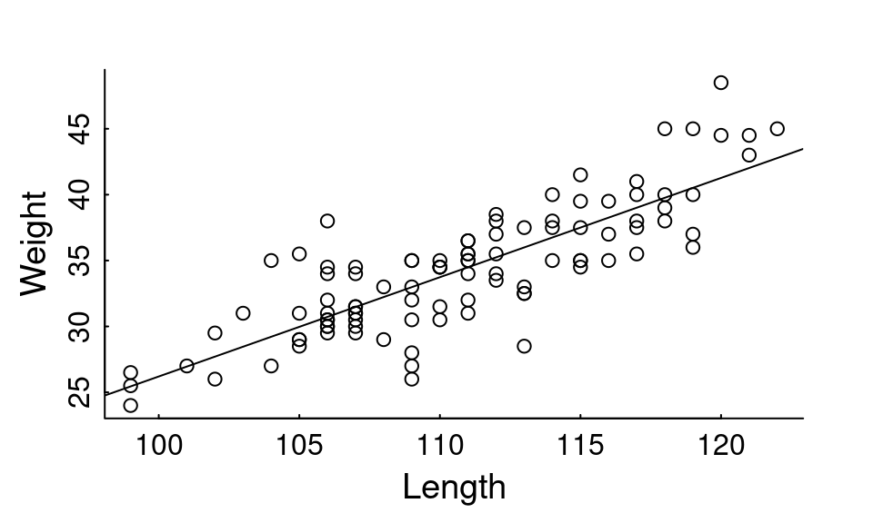

```r
plot(Weight ~ Length, data = pups)
abline(my_model)
```

The `abline` puts a line, with intercpt `a` and slope `b` onto a figure.

## Fitting linear models is easy!

**Confidence Interval**

Report the summary of the “model fit object”:

```r
summary(my_model)
```

```
##
## Call:
## lm(formula = Weight ~ Length, data = pups)
##
## Residuals:
##    Min     1Q Median     3Q    Max
## -7.498 -1.718  0.023  1.764  7.276
##
## Coefficients:
##              Estimate Std. Error t value Pr(>|t|)
## (Intercept) -49.14222    5.75796  -8.535 1.81e-13 ***
## Length        0.75345    0.05193  14.510  < 2e-16 ***
## ---
## Signif. codes:  0 '***' 0.001 '**' 0.01 '*' 0.05 '.' 0.1 ' ' 1
##
## Residual standard error: 2.761 on 98 degrees of freedom
## Multiple R-squared:  0.6824, Adjusted R-squared:  0.6791
## F-statistic: 210.5 on 1 and 98 DF,  p-value: < 2.2e-16
```

The “standard error” around the **Length** factor is 0.05.

The “true value” lies within **TWO** standard errors of the **point estimate** with 95% probability.

So the estimate of the slope with **confidence interval** is (in g/cm): \(\widehat{\beta} = 754 \,g/cm \pm 104\)

The \(p\)-value around the **Length** factor is \(<2 \times 10^{-16}\) .. i.e. **0** This says that there is NO chance that you would get this steep a slope if there were NO relationship between Length and Weight (the null hypothesis).

So we’ve performed both **estimation** and **hypothesis testing** with this model.

## WA sea otter data:

Source: https://wdfw.wa.gov/species-habitats/species/enhydra-lutris-kenyoni

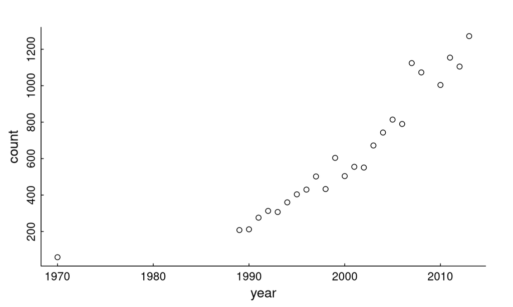

```r
WA <- read.csv("data/WA_SeaOtters_PopGrowth.csv")
plot(WA)
```

## Fit a linear model

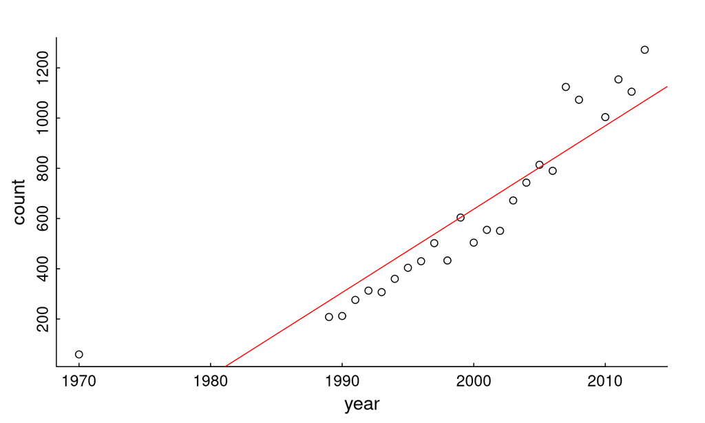

```r
WA_lm <- lm(count ~ year, data = WA)
plot(WA); abline(WA_lm, col = "red")
```

**What are some problems with this model1?**

## Plot on Log scale: Much more linear looking!

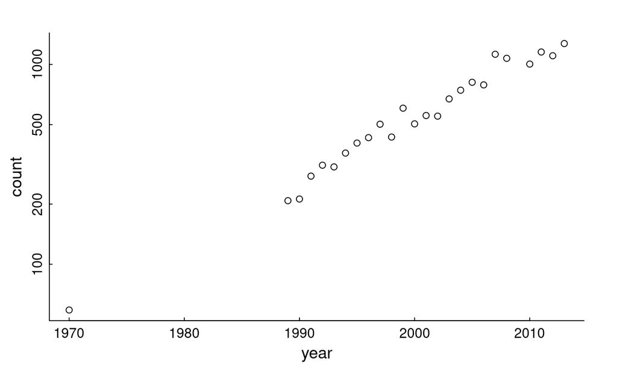

```r
plot(WA, log = "y")
```

### Linear model of *log(count)*

```r
logWA_lm <- lm(log(count) ~ year, data = WA)
logWA_lm
```

```
##
## Call:
## lm(formula = log(count) ~ year, data = WA)
##
## Coefficients:
## (Intercept)         year
##  -140.22274      0.07325
```

### A little math:

\[\log(N_i) = \alpha + \beta \, Y_i\] \[N_i = \exp(\alpha) \times \exp(\beta \, Y_i)\] \[N_i = e^\alpha {e^\beta}^{Y_i}\] \[N_i = N_0 \lambda ^ {Y_i}\]

\[\lambda = e^{\beta} = e^{0.07325} = 1.076\]

SO … percent rate of growth is about 7.6%.

## Plot exponential growth

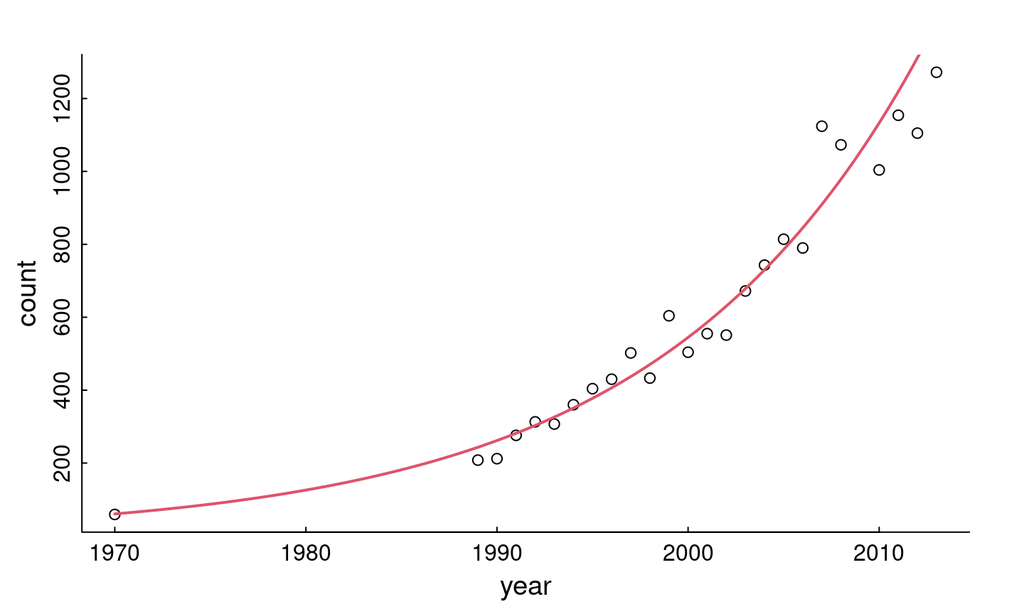

```r
plot(count~year, data = WA)
curve(exp(-140.2 + 0.07325 * x), add = TRUE, col = 2, lwd = 2)
```

Nice fit!

## 95% confidence intervals

### Summary stats of model:

```r
summary(logWA_lm)$coefficients
```

```
##                  Estimate  Std. Error   t value     Pr(>|t|)
## (Intercept) -140.22274000 4.731750915 -29.63443 7.960617e-20
## year           0.07325146 0.002366513  30.95333 2.993740e-20
```

Extract 95% confidence interval:

\[\widehat{\beta} = 0.07325 \pm 2\times{0.0023} = \{0.0685, 0.0780\}\] \[\widehat{\lambda} = \exp(0.07325 \pm 2\times{0.0023}) = \{1.071, 1.081\}\] So annual growth rate is \(7.6\% \pm 0.5\), with 95% Confidence.

**Key takeaway:** With linear modeling we can (a) use ALL the data to (b) quantify **uncertainty** on our estimate of growth rate.